# Data Science I, Workshop I: Predicting interest rates at the Lending Club

# 7 Sample size estimation and learning curves

We can use the hold out method for out-of-sample testing to check if we have a sufficiently large sample to estimate the model reliably. The idea is to set aside some of the data as a testing set. From the remaining data draw progressively larger training sets and check how the performance of the model on the testing set changes. If the performance no longer improves with larger training sets we know we have a large enough sample. The code below does this. Examine it and run it with different random seeds.

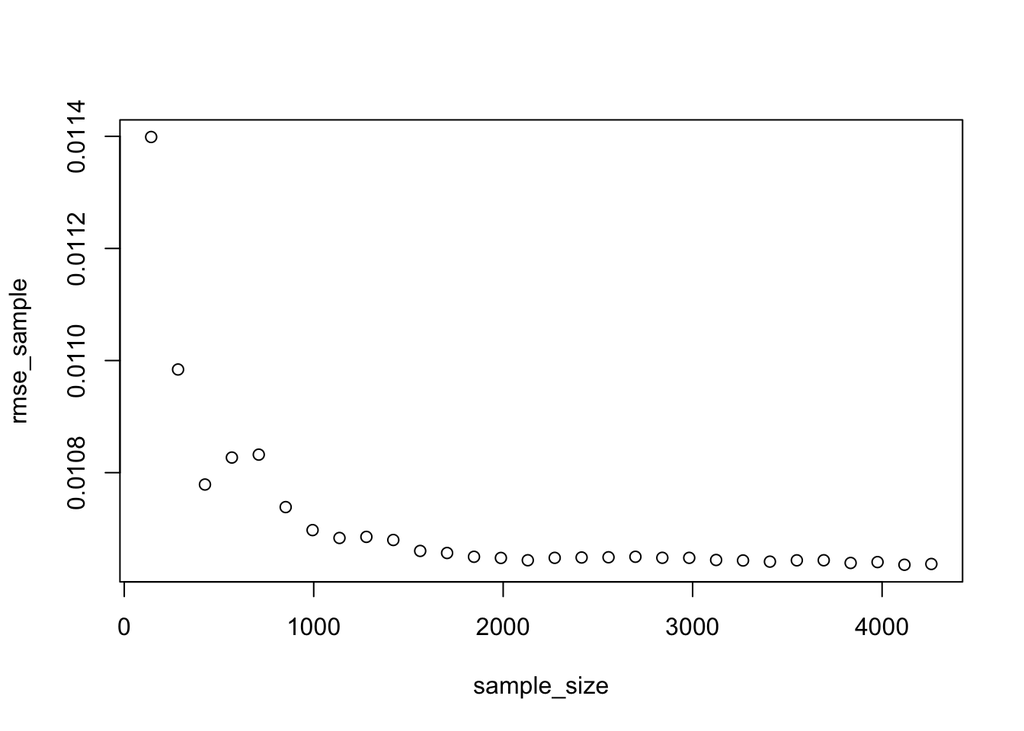

```r
#select a testing dataset (25% of all data)
set.seed(12)

train_test_split <- initial_split(lc_clean, prop = 0.75) #comemnt on evey line
remaining <- training(train_test_split)
testing <- testing(train_test_split)

#We are now going to run 30 models starting from a tiny training set drawn from the training data and progressively increasing its size. The testing set remains the same in all iterations.

#initiating the model by setting some parameters to zero
rmse_sample <- 0
sample_size<-0
Rsq_sample<-0

for(i in 1:30) {
#from the remaining dataset select a smaller subset to training the data
set.seed(100)
sample

  learning_split <- initial_split(remaining, prop = i/200)
  training <- training(learning_split)
  sample_size[i]=nrow(training)

  #traing the model on the small dataset
  model3<-lm(int_rate ~ loan_amnt + term+ dti + annual_inc + grade + grade:loan_amnt, training)
  #test the performance of the model on the large testing dataset. This stays fixed for all iterations.
  pred<-predict(model3,testing)
  rmse_sample[i]<-RMSE(pred,testing$int_rate)
  Rsq_sample[i]<-R2(pred,testing$int_rate)
}
plot(sample_size,rmse_sample)
```

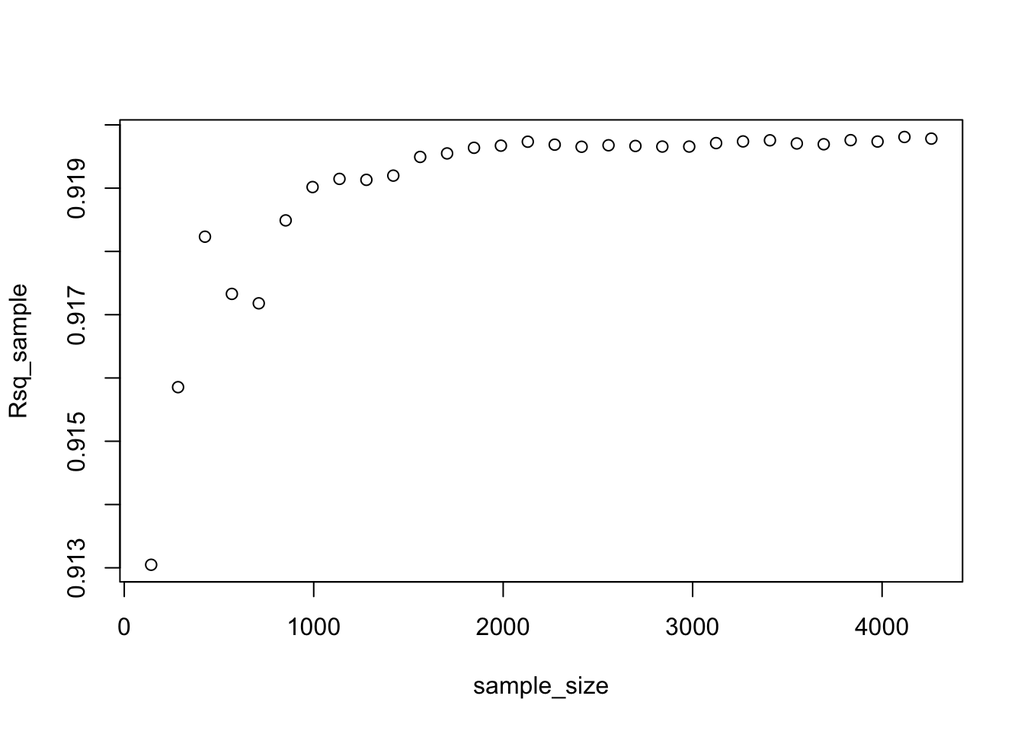

```r
plot(sample_size,Rsq_sample)
```

## Q6. Using the learning curves above, approximately how large of a sample size would we need to estimate model 3 reliably? Once we reach this sample size, if we want to reduce the prediction error further what options do we have?

# 8 Regularization using LASSO regression

If we are in the region of the learning curve where we do not have enough data, one option is to use a regularization method such as LASSO.

Let’s try to estimate a large and complicated model (many interactions and polynomials) on a small training dataset using OLS regression and hold-out validation method.

```r
#split the data in testing and training. The training test is really small.
set.seed(1234)
train_test_split <- initial_split(lc_clean, prop = 0.01)
training <- training(train_test_split)
testing <- testing(train_test_split)

model_lm<-lm(int_rate ~ poly(loan_amnt,3) + term+ dti + annual_inc + grade +grade:poly(loan_amnt,3):term +poly(loan_amnt,3):term +grade:term, training)
predictions <- predict(model_lm,testing)

# Model prediction performance
data.frame(
  RMSE = RMSE(predictions, testing$int_rate),
  Rsquare = R2(predictions, testing$int_rate)
)
```

| RMSE | Rsquare |
| --- | --- |
| 0.0123 | 0.891 |

Not surprisingly this model does not perform well – as we knew form the learning curves we constructed for a simpler model we need a lot more data to estimate this model reliably. Try running it again with different seeds. The model’s performance tends to be sensitive to the choice of the training set.

```r
# we will look for the optimal lambda in this sequence (we will try 1000 different lambdas, feel free to try more if necessary)
lambda_seq <- seq(0, 0.01, length = 1000)

# lasso regression using k-fold cross validation to select the best lambda

lasso <- train(
 int_rate ~ poly(loan_amnt,3) + term+ dti + annual_inc + grade +grade:poly(loan_amnt,3):term +poly(loan_amnt,3):term +grade:term,
 data = training,
 method = "glmnet",
  preProc = c("center", "scale"), #This option standardizes the data before running the LASSO regression
  trControl = control,
  tuneGrid = expand.grid(alpha = 1, lambda = lambda_seq) #alpha=1 specifies to run a LASSO regression. If alpha=0 the model would run ridge regression.
  )
# Model coefficients
coef(lasso$finalModel, lasso$bestTune$lambda)
```

```
## 58 x 1 sparse Matrix of class "dgCMatrix"
##                                              s1
## (Intercept)                        1.211648e-01
## poly(loan_amnt, 3)1                8.174842e-04
## poly(loan_amnt, 3)2                .
## poly(loan_amnt, 3)3                2.679139e-04
## term60                             1.310599e-03
## dti                                4.533903e-04
## annual_inc                         .
## gradeB                             1.694549e-02
## gradeC                             2.340075e-02
## gradeD                             2.497771e-02
## gradeE                             2.493928e-02
## gradeF                             1.900285e-02
## gradeG                             1.746985e-02
## poly(loan_amnt, 3)1:term60         .
## poly(loan_amnt, 3)2:term60         .
## poly(loan_amnt, 3)3:term60         .
## term60:gradeB                     -8.723001e-04
## term60:gradeC                      .
## term60:gradeD                      5.646345e-04
## term60:gradeE                      1.739572e-03
## term60:gradeF                      6.847230e-04
## term60:gradeG                      1.626767e-03
## poly(loan_amnt, 3)1:term36:gradeB  .
## poly(loan_amnt, 3)2:term36:gradeB  .
## poly(loan_amnt, 3)3:term36:gradeB  4.389468e-04
## poly(loan_amnt, 3)1:term60:gradeB  .
## poly(loan_amnt, 3)2:term60:gradeB  4.795900e-04
## poly(loan_amnt, 3)3:term60:gradeB  .
## poly(loan_amnt, 3)1:term36:gradeC  .
## poly(loan_amnt, 3)2:term36:gradeC  3.542283e-04
## poly(loan_amnt, 3)3:term36:gradeC -2.844958e-04
## poly(loan_amnt, 3)1:term60:gradeC  .
## poly(loan_amnt, 3)2:term60:gradeC  .
## poly(loan_amnt, 3)3:term60:gradeC -3.757415e-04
## poly(loan_amnt, 3)1:term36:gradeD  .
## poly(loan_amnt, 3)2:term36:gradeD  5.795450e-04
## poly(loan_amnt, 3)3:term36:gradeD  2.945142e-04
## poly(loan_amnt, 3)1:term60:gradeD  .
## poly(loan_amnt, 3)2:term60:gradeD  .
## poly(loan_amnt, 3)3:term60:gradeD -6.776135e-05
## poly(loan_amnt, 3)1:term36:gradeE  .
## poly(loan_amnt, 3)2:term36:gradeE  .
## poly(loan_amnt, 3)3:term36:gradeE  .
## poly(loan_amnt, 3)1:term60:gradeE  .
## poly(loan_amnt, 3)2:term60:gradeE  .
## poly(loan_amnt, 3)3:term60:gradeE -4.872144e-04
## poly(loan_amnt, 3)1:term36:gradeF  .
## poly(loan_amnt, 3)2:term36:gradeF  .
## poly(loan_amnt, 3)3:term36:gradeF  .
## poly(loan_amnt, 3)1:term60:gradeF  .
## poly(loan_amnt, 3)2:term60:gradeF  .
## poly(loan_amnt, 3)3:term60:gradeF  1.396305e-03
## poly(loan_amnt, 3)1:term36:gradeG  .
## poly(loan_amnt, 3)2:term36:gradeG  .
## poly(loan_amnt, 3)3:term36:gradeG  .
## poly(loan_amnt, 3)1:term60:gradeG  .
## poly(loan_amnt, 3)2:term60:gradeG  4.725762e-04
## poly(loan_amnt, 3)3:term60:gradeG  .
```

```r
# Best lambda
lasso$bestTune$lambda
```

```
## [1] 0.0003103103
```

```r
# Count of how many coefficients are greater than zero and how many are equal to zero

sum(coef(lasso$finalModel, lasso$bestTune$lambda)!=0)
```

```
## [1] 27
```

```r
sum(coef(lasso$finalModel, lasso$bestTune$lambda)==0)
```

```
## [1] 31
```

```r
# Make predictions
predictions <- predict(lasso,testing)
```

```r
# Model prediction performance

data.frame(
  RMSE = RMSE(predictions, testing$int_rate),
  Rsquare = R2(predictions, testing$int_rate)
)
```

| RMSE | Rsquare |
| --- | --- |
| 0.0108 | 0.917 |

# 9 Using Time Information

Let’s try to further improve the model’s predictive performance. So far we have not used any time series information. Effectively, all things being equal, our prediction for the interest rate of a loan given in 2009 would be the same as that of a loan given in 2011. Is this a good assumption?

First, investigate graphically whether there are any time trends in the interest rates. (Note that the variable “issue_d” only has information on the month the loan was awarded but not the exact date.) Can you use this information to further improve the forecasting accuracy of your model? Try controlling for time in a linear fashion (i.e., a linear time trend) and controlling for time as quarter-year dummies (this is a method to capture non-linear effects of time – we assume that the impact of time doesn’t change within a quarter but it can chance from quarter to quarter). Finally, check if time affect loans of different grades differently.

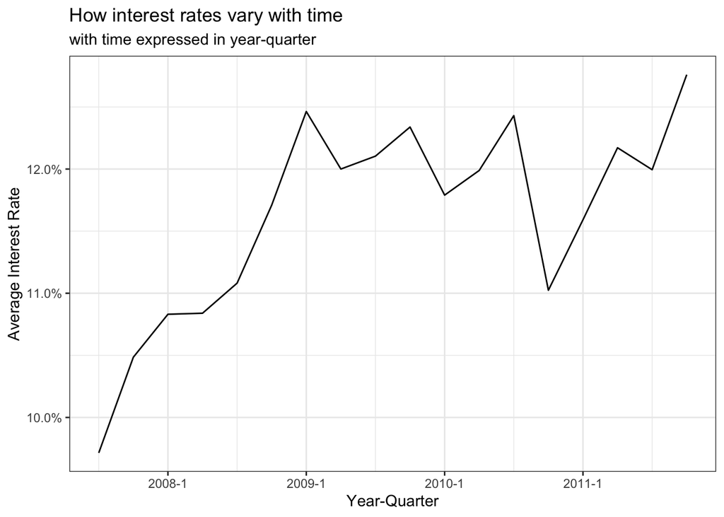

```r
#linear time trend (add code below)
lc_clean$issue_d = as.Date(lc_clean$issue_d)

#add a column which indicates year-quarter
lc_clean <- lc_clean %>%
  mutate(qtr= as.yearqtr(issue_d))

#calculate the mean interest rate for each quarter
lc_clean_time <- lc_clean %>%
  select(int_rate, qtr) %>%
    #since there is only 1 observation in 2007-Q2 which would not be representative for the entire quarter, we decide to remove it
  filter(qtr != "2007 Q2") %>%
  group_by(qtr) %>%
  summarise(avg_int_rate = mean(int_rate))

#plot the time series average interest rate based on quarters
time_trend <- lc_clean_time %>%
  ggplot(aes(x = qtr,y = avg_int_rate))+
  geom_line()+
  scale_y_continuous(labels = scales::percent)+
  labs(title = "How interest rates vary with time",
       subtitle = "with time expressed in year-quarter",
      x = "Year-Quarter",
       y = "Average Interest Rate")+
  theme_bw()

#visualize
time_trend
```

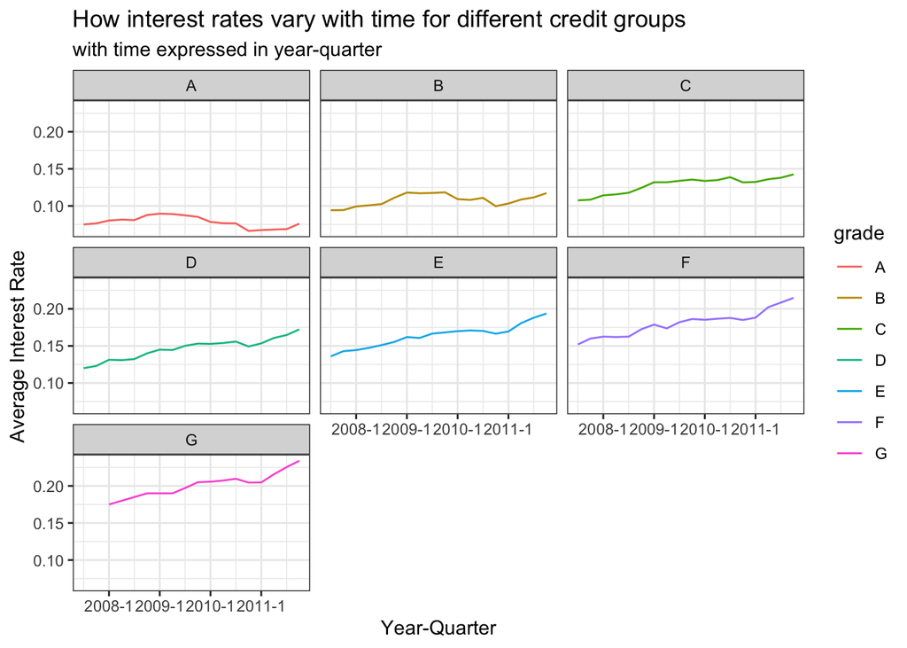

```r
#linear time trend by grade (add code below)
lc_clean_grade <- lc_clean %>%
  select(int_rate, grade, qtr) %>%
  #since there is only 1 observation in 2007-Q2 which would not be representative for the entire quarter, we decide to remove it
  filter(qtr != "2007 Q2") %>%
  group_by(qtr,grade) %>%
  summarise(avg_int_rate = mean(int_rate))

#plot the time series average interest rate based on quarters
time_trend_by_grade <- lc_clean_grade %>%
  ggplot(aes(x = qtr,y = avg_int_rate, group = grade))+
  geom_line(aes(color=grade))+
  facet_wrap(~grade)+
  labs(title = "How interest rates vary with time for different credit groups",
       subtitle = "with time expressed in year-quarter",
      x = "Year-Quarter",
       y = "Average Interest Rate")+
  theme_bw()

#visualize
time_trend_by_grade
```

Based on the graph above, grade C to G has an increase of interest rate over time, while grade A and B remains relatively stable. We can also see that before 2011, interest rate grows steadily in grade C to G while after 2011 it spiked.

```r
#Train models using OLS regression and k-fold cross-validation
#base model without time trend variable
time0<-train(
  #explanatory variables
  int_rate ~ loan_amnt + term + loan_amnt*grade + log(annual_inc),
  lc_clean,
  method = "lm",
  trControl = control)
summary(time0)
```

```
##
## Call:
## lm(formula = .outcome ~ ., data = dat)
##
## Residuals:
##       Min        1Q    Median        3Q       Max
## -0.119768 -0.007324 -0.000030  0.006585  0.037603
##
## Coefficients:
##                      Estimate Std. Error t value Pr(>|t|)
## (Intercept)         7.661e-02  1.172e-03  65.396  < 2e-16 ***
## loan_amnt           1.644e-07  2.052e-08   8.009 1.19e-15 ***
## term60              3.791e-03  1.425e-04  26.614  < 2e-16 ***
## gradeB              3.626e-02  2.731e-04 132.797  < 2e-16 ***
## gradeC              6.200e-02  2.988e-04 207.498  < 2e-16 ***
## gradeD              8.081e-02  3.484e-04 231.900  < 2e-16 ***
## gradeE              9.632e-02  4.625e-04 208.247  < 2e-16 ***
## gradeF              1.142e-01  7.736e-04 147.670  < 2e-16 ***
## gradeG              1.326e-01  1.551e-03  85.497  < 2e-16 ***
## `log(annual_inc)`  -4.219e-04  1.083e-04  -3.897 9.77e-05 ***
## `loan_amnt:gradeB` -6.672e-08  2.442e-08  -2.732  0.00629 **
## `loan_amnt:gradeC` -1.682e-07  2.621e-08  -6.419 1.39e-10 ***
## `loan_amnt:gradeD`  7.109e-08  2.798e-08   2.541  0.01106 *
## `loan_amnt:gradeE`  2.241e-07  3.015e-08   7.432 1.09e-13 ***
## `loan_amnt:gradeF`  2.813e-07  4.135e-08   6.802 1.05e-11 ***
## `loan_amnt:gradeG`  1.353e-07  7.258e-08   1.864  0.06231 .
## ---
## Signif. codes:  0 '***' 0.001 '**' 0.01 '*' 0.05 '.' 0.1 ' ' 1
##
## Residual standard error: 0.01052 on 37853 degrees of freedom
## Multiple R-squared:  0.9204, Adjusted R-squared:  0.9203
## F-statistic: 2.917e+04 on 15 and 37853 DF,  p-value: < 2.2e-16
```

```r
#Train models using OLS regression and k-fold cross-validation
#The first model has some explanatory variables and a linear time trend

#convert issue_d date variable from discrete to continuous variable
temp <- lc_clean
temp$issue_d=as.POSIXct(temp$issue_d)
min=min(temp$issue_d)
temp <- temp %>%
  mutate(seq_month = as.numeric(difftime(temp$issue_d,min,units='days'))/30)

#fit the model
time1<-train(
  #explanatory variables
  int_rate ~ loan_amnt + term + loan_amnt*grade + log(annual_inc) +
    #time variable of sequencial number of the month
    seq_month,
  temp,
  method = "lm",
  trControl = control)
summary(time1)
```

```
##
## Call:
## lm(formula = .outcome ~ ., data = dat)
##
## Residuals:
##       Min        1Q    Median        3Q       Max
## -0.119014 -0.006591 -0.000741  0.006938  0.036179
##
## Coefficients:
##                      Estimate Std. Error t value Pr(>|t|)
## (Intercept)         6.854e-02  1.167e-03  58.722  < 2e-16 ***
## loan_amnt           1.019e-07  2.019e-08   5.049 4.46e-07 ***
## term60              2.232e-03  1.453e-04  15.361  < 2e-16 ***
## gradeB              3.608e-02  2.678e-04 134.733  < 2e-16 ***
## gradeC              6.245e-02  2.932e-04 212.981  < 2e-16 ***
## gradeD              8.128e-02  3.419e-04 237.728  < 2e-16 ***
## gradeE              9.727e-02  4.542e-04 214.166  < 2e-16 ***
## gradeF              1.152e-01  7.590e-04 151.828  < 2e-16 ***
## gradeG              1.336e-01  1.521e-03  87.856  < 2e-16 ***
## `log(annual_inc)`  -3.928e-04  1.062e-04  -3.700 0.000216 ***
## seq_month           1.967e-04  5.051e-06  38.946  < 2e-16 ***
## `loan_amnt:gradeB` -6.849e-11  2.400e-08  -0.003 0.997723
## `loan_amnt:gradeC` -1.196e-07  2.573e-08  -4.646 3.39e-06 ***
## `loan_amnt:gradeD`  1.160e-07  2.746e-08   4.223 2.41e-05 ***
## `loan_amnt:gradeE`  2.469e-07  2.957e-08   8.350  < 2e-16 ***
## `loan_amnt:gradeF`  3.020e-07  4.055e-08   7.447 9.76e-14 ***
## `loan_amnt:gradeG`  1.622e-07  7.117e-08   2.278 0.022704 *
## ---
## Signif. codes:  0 '***' 0.001 '**' 0.01 '*' 0.05 '.' 0.1 ' ' 1
##
## Residual standard error: 0.01031 on 37852 degrees of freedom
## Multiple R-squared:  0.9234, Adjusted R-squared:  0.9234
## F-statistic: 2.853e+04 on 16 and 37852 DF,  p-value: < 2.2e-16
```

We can see that based on the result above, the time variable `seq_month` has significant explanatory power since the p-value is <2e-16, which is less than 5%. Compared to model0, the rse decreased from 0.01052 to 0.01031, i.e., 2%; the R^2 increased from 0.9203 to 0.9234, i.e., 0.34%. We can conclude by including time variable into our model, the performance is better.

```r
#The second model has a different linear time trend for each grade class
time2<-train(
    int_rate ~ loan_amnt + term + loan_amnt*grade + log(annual_inc) +
      grade +grade:seq_month, #fill your variables here
    temp,
   method = "lm",
    trControl = control
   )
summary(time2)
```

```
##
## Call:
## lm(formula = .outcome ~ ., data = dat)
##
## Residuals:
##       Min        1Q    Median        3Q       Max
## -0.120888 -0.006623 -0.000137  0.006753  0.031124
##
## Coefficients:
##                      Estimate Std. Error t value Pr(>|t|)
## (Intercept)         9.441e-02  1.071e-03  88.135  < 2e-16 ***
## loan_amnt           3.182e-07  1.791e-08  17.764  < 2e-16 ***
## term60             -6.279e-04  1.304e-04  -4.814 1.49e-06 ***
## gradeB              1.503e-02  5.248e-04  28.631  < 2e-16 ***
## gradeC              2.974e-02  5.455e-04  54.509  < 2e-16 ***
## gradeD              3.473e-02  6.395e-04  54.317  < 2e-16 ***
## gradeE              4.260e-02  8.663e-04  49.178  < 2e-16 ***
## gradeF              5.136e-02  1.437e-03  35.743  < 2e-16 ***
## gradeG              6.804e-02  2.962e-03  22.969  < 2e-16 ***
## `log(annual_inc)`  -4.944e-04  9.322e-05  -5.304 1.14e-07 ***
## `loan_amnt:gradeB` -1.547e-07  2.124e-08  -7.285 3.29e-13 ***
## `loan_amnt:gradeC` -3.187e-07  2.283e-08 -13.959  < 2e-16 ***
## `loan_amnt:gradeD` -1.702e-07  2.435e-08  -6.990 2.80e-12 ***
## `loan_amnt:gradeE` -1.650e-07  2.658e-08  -6.207 5.45e-10 ***
## `loan_amnt:gradeF` -1.775e-07  3.677e-08  -4.827 1.39e-06 ***
## `loan_amnt:gradeG` -2.800e-07  6.440e-08  -4.348 1.38e-05 ***
## `gradeA:seq_month` -4.272e-04  8.776e-06 -48.677  < 2e-16 ***
## `gradeB:seq_month`  1.075e-04  7.759e-06  13.853  < 2e-16 ***
## `gradeC:seq_month`  4.108e-04  8.893e-06  46.192  < 2e-16 ***
## `gradeD:seq_month`  7.736e-04  1.160e-05  66.691  < 2e-16 ***
## `gradeE:seq_month`  1.007e-03  1.801e-05  55.887  < 2e-16 ***
## `gradeF:seq_month`  1.236e-03  3.136e-05  39.411  < 2e-16 ***
## `gradeG:seq_month`  1.276e-03  6.635e-05  19.229  < 2e-16 ***
## ---
## Signif. codes:  0 '***' 0.001 '**' 0.01 '*' 0.05 '.' 0.1 ' ' 1
##
## Residual standard error: 0.009054 on 37846 degrees of freedom
## Multiple R-squared:  0.941,  Adjusted R-squared:  0.941
## F-statistic: 2.744e+04 on 22 and 37846 DF,  p-value: < 2.2e-16
```

For all the 7 additional interaction term, the p-values have significant explanatory power since they are less than 5%. Compared to model1, the rse decreased from 0.01031 to 0.009054, i.e., 12.18%; the R^2 increased from 0.9234 to 0.941, i.e., 1.9%. We can conclude by including interaction variable `grade:seq_month` variable into our model, the performance is better.

```r
#Change the time trend to a quarter dummy variables.
#zoo::as.yearqrt() creates quarter dummies
lc_clean_quarter<-lc_clean %>%
  mutate(yq = as.factor(as.yearqtr(lc_clean$issue_d, format = "%Y-%m-%d")))



time3<-train(
    int_rate ~ loan_amnt + term + loan_amnt*grade + log(annual_inc) + grade +
    yq,#fill your variables here
    lc_clean_quarter,
     method = "lm",
    trControl = control
   )
summary(time3)
```

```
##
## Call:
## lm(formula = .outcome ~ ., data = dat)
##
## Residuals:
##       Min        1Q    Median        3Q       Max
## -0.116044 -0.005413 -0.000214  0.005798  0.037733
##
## Coefficients:
##                      Estimate Std. Error t value Pr(>|t|)
## (Intercept)         3.982e-02  9.121e-03   4.366 1.27e-05 ***
## loan_amnt           1.095e-07  1.781e-08   6.146 8.02e-10 ***
## term60              4.568e-03  1.310e-04  34.861  < 2e-16 ***
## gradeB              3.659e-02  2.357e-04 155.202  < 2e-16 ***
## gradeC              6.249e-02  2.582e-04 242.000  < 2e-16 ***
## gradeD              8.096e-02  3.010e-04 268.963  < 2e-16 ***
## gradeE              9.699e-02  3.999e-04 242.525  < 2e-16 ***
## gradeF              1.154e-01  6.678e-04 172.738  < 2e-16 ***
## gradeG              1.338e-01  1.338e-03  99.989  < 2e-16 ***
## `log(annual_inc)`  -1.501e-04  9.352e-05  -1.605 0.108399
## `yq2007 Q3`         1.926e-02  9.136e-03   2.108 0.035046 *
## `yq2007 Q4`         1.480e-02  9.103e-03   1.626 0.103991
## `yq2008 Q1`         2.124e-02  9.082e-03   2.339 0.019351 *
## `yq2008 Q2`         2.288e-02  9.090e-03   2.517 0.011850 *
## `yq2008 Q3`         2.403e-02  9.100e-03   2.641 0.008277 **
## `yq2008 Q4`         3.196e-02  9.083e-03   3.518 0.000435 ***
## `yq2009 Q1`         3.613e-02  9.080e-03   3.980 6.92e-05 ***
## `yq2009 Q2`         3.798e-02  9.078e-03   4.183 2.88e-05 ***
## `yq2009 Q3`         3.952e-02  9.077e-03   4.353 1.34e-05 ***
## `yq2009 Q4`         3.977e-02  9.076e-03   4.382 1.18e-05 ***
## `yq2010 Q1`         3.475e-02  9.076e-03   3.829 0.000129 ***
## `yq2010 Q2`         3.350e-02  9.075e-03   3.691 0.000224 ***
## `yq2010 Q3`         3.459e-02  9.075e-03   3.812 0.000138 ***
## `yq2010 Q4`         2.587e-02  9.075e-03   2.851 0.004360 **
## `yq2011 Q1`         2.800e-02  9.075e-03   3.086 0.002030 **
## `yq2011 Q2`         3.317e-02  9.075e-03   3.655 0.000257 ***
## `yq2011 Q3`         3.557e-02  9.075e-03   3.920 8.88e-05 ***
## `yq2011 Q4`         4.180e-02  9.074e-03   4.606 4.12e-06 ***
## `loan_amnt:gradeB` -1.079e-07  2.117e-08  -5.097 3.46e-07 ***
## `loan_amnt:gradeC` -2.140e-07  2.271e-08  -9.425  < 2e-16 ***
## `loan_amnt:gradeD`  5.935e-08  2.421e-08   2.452 0.014231 *
## `loan_amnt:gradeE`  1.822e-07  2.608e-08   6.986 2.88e-12 ***
## `loan_amnt:gradeF`  2.271e-07  3.572e-08   6.359 2.06e-10 ***
## `loan_amnt:gradeG`  1.143e-07  6.262e-08   1.826 0.067870 .
## ---
## Signif. codes:  0 '***' 0.001 '**' 0.01 '*' 0.05 '.' 0.1 ' ' 1
##
## Residual standard error: 0.00907 on 37835 degrees of freedom
## Multiple R-squared:  0.9408, Adjusted R-squared:  0.9408
## F-statistic: 1.822e+04 on 33 and 37835 DF,  p-value: < 2.2e-16
```

```r
#We specify one quarter dummy variable for each grade. This is going to be a large model as there are 19 quarters x 7 grades = 133 quarter-grade dummies.
time4<-train(
    int_rate ~  loan_amnt + term + loan_amnt*grade + log(annual_inc) + grade +
    grade:yq, #fill your variables here
    lc_clean_quarter,
     method = "lm",
    trControl = control
   )
summary(time4)
```

```
##
## Call:
## lm(formula = .outcome ~ ., data = dat)
##
## Residuals:
##       Min        1Q    Median        3Q       Max
## -0.120563 -0.004913  0.000310  0.004689  0.034349
##
## Coefficients: (11 not defined because of singularities)
##                      Estimate Std. Error t value Pr(>|t|)
## (Intercept)         7.545e-02  8.627e-04  87.456  < 2e-16 ***
## loan_amnt           3.033e-07  1.514e-08  20.025  < 2e-16 ***
## term60              1.728e-03  1.131e-04  15.274  < 2e-16 ***
## gradeB              4.309e-02  3.194e-04 134.891  < 2e-16 ***
## gradeC              6.976e-02  3.625e-04 192.466  < 2e-16 ***
## gradeD              9.700e-02  4.192e-04 231.389  < 2e-16 ***
## gradeE              6.373e-02  7.575e-03   8.414  < 2e-16 ***
## gradeF              1.389e-01  8.643e-04 160.683  < 2e-16 ***
## gradeG              1.601e-01  1.802e-03  88.854  < 2e-16 ***
## `log(annual_inc)`  -2.315e-04  7.818e-05  -2.961 0.003070 **
## `loan_amnt:gradeB` -2.443e-07  1.795e-08 -13.611  < 2e-16 ***
## `loan_amnt:gradeC` -3.670e-07  1.928e-08 -19.029  < 2e-16 ***
## `loan_amnt:gradeD` -2.059e-07  2.056e-08 -10.014  < 2e-16 ***
## `loan_amnt:gradeE` -2.189e-07  2.256e-08  -9.704  < 2e-16 ***
## `loan_amnt:gradeF` -2.417e-07  3.155e-08  -7.660 1.90e-14 ***
## `loan_amnt:gradeG` -3.302e-07  5.655e-08  -5.839 5.30e-09 ***
## `gradeA:yq2007 Q3`  6.654e-04  1.499e-03   0.444 0.657040
## `gradeB:yq2007 Q3` -2.211e-02  1.747e-03 -12.658  < 2e-16 ***
## `gradeC:yq2007 Q3` -3.471e-02  1.907e-03 -18.205  < 2e-16 ***
## `gradeD:yq2007 Q3` -5.071e-02  3.398e-03 -14.923  < 2e-16 ***
## `gradeE:yq2007 Q3` -1.961e-03  9.272e-03  -0.211 0.832522
## `gradeF:yq2007 Q3` -6.021e-02  3.451e-03 -17.446  < 2e-16 ***
## `gradeG:yq2007 Q3`         NA         NA      NA       NA
## `gradeA:yq2007 Q4`  1.705e-03  1.444e-03   1.181 0.237682
## `gradeB:yq2007 Q4` -2.225e-02  1.310e-03 -16.989  < 2e-16 ***
## `gradeC:yq2007 Q4` -3.364e-02  1.074e-03 -31.314  < 2e-16 ***
## `gradeD:yq2007 Q4` -4.804e-02  1.484e-03 -32.363  < 2e-16 ***
## `gradeE:yq2007 Q4`  5.066e-03  7.908e-03   0.641 0.521794
## `gradeF:yq2007 Q4` -5.291e-02  7.590e-03  -6.972 3.18e-12 ***
## `gradeG:yq2007 Q4`         NA         NA      NA       NA
```

[output cut: 103 more lines]

```
## `gradeF:yq2011 Q3` -6.072e-03  8.171e-04  -7.432 1.09e-13 ***
## `gradeG:yq2011 Q3` -8.754e-03  1.622e-03  -5.397 6.83e-08 ***
## `gradeA:yq2011 Q4`         NA         NA      NA       NA
## `gradeB:yq2011 Q4`         NA         NA      NA       NA
## `gradeC:yq2011 Q4`         NA         NA      NA       NA
## `gradeD:yq2011 Q4`         NA         NA      NA       NA
## `gradeE:yq2011 Q4`  5.390e-02  7.581e-03   7.110 1.18e-12 ***
## `gradeF:yq2011 Q4`         NA         NA      NA       NA
## `gradeG:yq2011 Q4`         NA         NA      NA       NA
## ---
## Signif. codes:  0 '***' 0.001 '**' 0.01 '*' 0.05 '.' 0.1 ' ' 1
##
## Residual standard error: 0.007569 on 37738 degrees of freedom
## Multiple R-squared:  0.9589, Adjusted R-squared:  0.9587
## F-statistic:  6769 on 130 and 37738 DF,  p-value: < 2.2e-16
```

## Q8 Based on your analysis above, is there any evidence to suggest that interest rates change over time? Does including time trends / quarter-year dummies improve predictions? Any improvement in prediction performance?

```r
#organising our results
time0_result <- data.frame(
  #base model variables
  time0$results$RMSE,
  time0$results$Rsquared)

  #base model variables + month variable
time1_result <- data.frame(
  time1$results$RMSE,
  time1$results$Rsquared)

  #base model variables + month variable*grade
time2_result <- data.frame(
  time2$results$RMSE,
  time2$results$Rsquared)

  #base model variables + quarter variable
time3_result <- data.frame(
  time3$results$RMSE,
  time3$results$Rsquared)

  #base model variables + quarter variable*grade
time4_result <- data.frame(
  time4$results$RMSE,
  time4$results$Rsquared)


time0_result
```

| time0.results.RMSE | time0.results.Rsquared |
| --- | --- |
| 0.0105 | 0.92 |

```r
time1_result
```

| time1.results.RMSE | time1.results.Rsquared |
| --- | --- |
| 0.0103 | 0.923 |

```r
time2_result
```

| time2.results.RMSE | time2.results.Rsquared |
| --- | --- |
| 0.00905 | 0.941 |

```r
time3_result
```

| time3.results.RMSE | time3.results.Rsquared |
| --- | --- |
| 0.00908 | 0.941 |

```r
time4_result
```

| time4.results.RMSE | time4.results.Rsquared |
| --- | --- |
| 0.00759 | 0.959 |

> - Compared to model0, model1’s rse decreased from 0.01052 to 0.01031, i.e., 2%; the R^2 increased from 0.9203 to 0.9234, i.e., 0.34%. We can conclude by including time variable into our model, the performance is better.
> - Compared to model1, model2’s rse decreased from 0.01031 to 0.009054, i.e., 12.18%; the R^2 increased from 0.9234 to 0.941, i.e., 1.9%. We can conclude by including interaction variable `grade:seq_month` variable into our model, the performance is better.
> - Compared to model1, model3’s rse decreased from 0.01031 to 0.00907, i.e., 12%; the R^2 increased from 0.9234 to 0.9408, i.e., 1.88%. We can conclude by including quarter variable `yq` into our model, the performance is better than the model including the month variable `seq_month`.
> - Compared to model3, model4’s rse decreased from 0.00907 to 0.007569, i.e., 16.5%; the R^2 increased from 0.9408 to 0.9587, i.e., 1.9%. We can conclude by including interaction variable `grade:yq` into our model, the performance is better than the model including the month variable `yq`.
> - In summary, we can see that by separating each grade and bring in time trend as variables, we will arrive at better prediction. And quarter variable has more explanatory power than month variable.

# 10 Using Bond Yields

One concern with using time trends for forecasting is that in order to make predictions for future loans we will need to project trends to the future. This is an extrapolation that may not be reasonable, especially if macroeconomic conditions in the future change. Furthermore, if we are using quarter-year dummies, it is not even possible to estimate the coefficient of these dummy variables for future quarters.

Instead, perhaps it’s better to find the reasons as to why different periods are different from one another. The csv file “MonthBondYields.csv” contains information on the yield of US Treasuries on the first day of each month. Can you use it to see if you can improve your predictions without using time dummies?

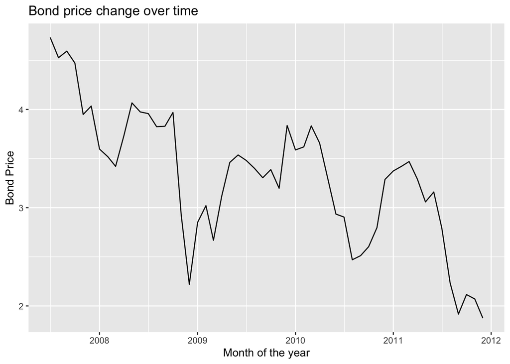

```r
#load the data to memory as a dataframe
bond_prices<-readr::read_csv("MonthBondYields .csv")

#make the date of the bond file comparable to the lending club dataset
#for some regional date/number (locale) settings this may not work.
#If it does try running the following line of code in the Console
#Sys.setlocale("LC_TIME","English")
bond_prices <- bond_prices %>%
  mutate(Date2=as.Date(paste("01",Date,sep="-"),"%d-%b-%y")) %>%
  select(-starts_with("X"))

#let's see what happened to bond yields over time.
#Lower bond yields mean the cost of borrowing has gone down.
bond_prices %>%
  ggplot(aes(x=Date2, y=Price))+geom_line() +
  labs(x="Month of the year",
       y="Bond Price",
       title="Bond price change over time")
```

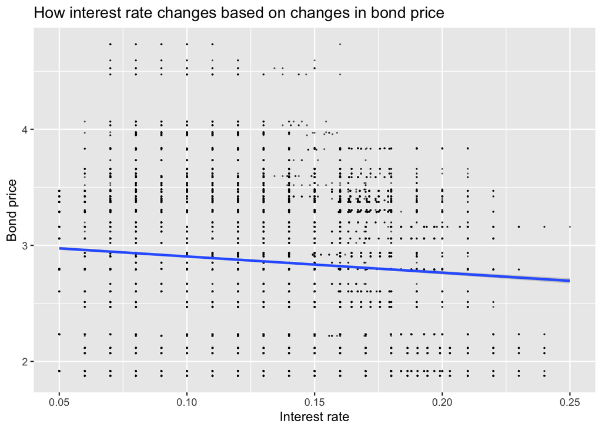

```r
#join the data using a left join
lc_with_bonds<-lc_clean %>%
  left_join(bond_prices, by = c("issue_d" = "Date2")) %>%
  arrange(issue_d) %>%
  filter(!is.na(Price)) #drop any observations where there re no bond prices available

# investigate graphically if there is a relationship
lc_with_bonds%>%
  ggplot(aes(x=int_rate, y=Price))+
  geom_point(size=0.1, alpha=0.5)+
  geom_smooth(method="lm")+
    labs(x="Interest rate",
       y="Bond price",
       title="How interest rate changes based on changes in bond price")
```

Based on the graph, we can see that the observations are quite scattered but follows a slightly negative correlation between interest rate and bond price.

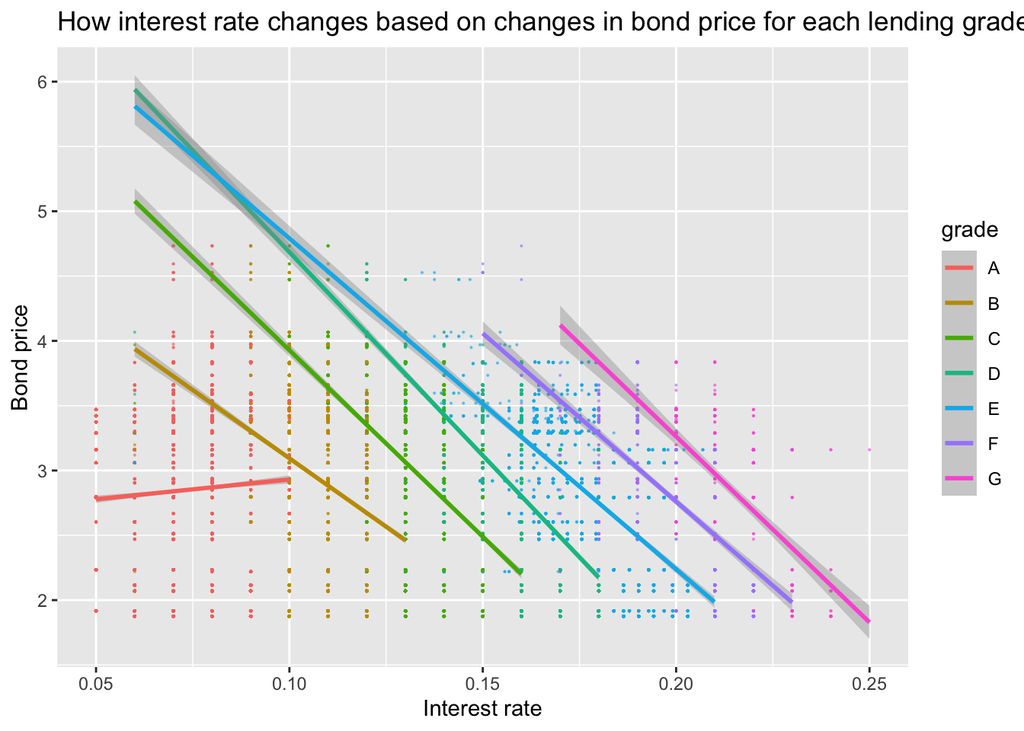

```r
#plot the relationship separately within each grade class
lc_with_bonds%>%
  ggplot(aes(x=int_rate, y=Price, color=grade))+
  geom_point(size=0.1, alpha=0.5)+
  geom_smooth(method="lm")+
  labs(x="Interest rate",
       y="Bond price",
       title="How interest rate changes based on changes in bond price for each lending grade",
       guide_legend="Grade")
```

```r
#let's fit the model by incorporating the bond price information with grade
model_bond<-train(
    int_rate ~ loan_amnt + term + loan_amnt*grade + log(annual_inc) + grade +
    grade:Price , #fill your variables here
    lc_with_bonds,
   method = "lm",
    trControl = control
   )
summary(model_bond)
```

```
##
## Call:
## lm(formula = .outcome ~ ., data = dat)
##
## Residuals:
##       Min        1Q    Median        3Q       Max
## -0.117803 -0.005764 -0.000317  0.006515  0.040834
##
## Coefficients:
##                      Estimate Std. Error t value Pr(>|t|)
## (Intercept)         7.229e-02  1.166e-03  61.998  < 2e-16 ***
## loan_amnt           1.920e-07  1.896e-08  10.127  < 2e-16 ***
## term60              1.489e-03  1.325e-04  11.232  < 2e-16 ***
## gradeB              5.349e-02  6.990e-04  76.524  < 2e-16 ***
## gradeC              8.629e-02  7.843e-04 110.027  < 2e-16 ***
## gradeD              1.191e-01  8.940e-04 133.220  < 2e-16 ***
## gradeE              1.432e-01  1.167e-03 122.739  < 2e-16 ***
## gradeF              1.666e-01  1.791e-03  93.038  < 2e-16 ***
## gradeG              1.901e-01  3.455e-03  55.024  < 2e-16 ***
## `log(annual_inc)`  -3.735e-04  9.869e-05  -3.785 0.000154 ***
## `loan_amnt:gradeB` -9.480e-08  2.249e-08  -4.216 2.49e-05 ***
## `loan_amnt:gradeC` -2.175e-07  2.415e-08  -9.006  < 2e-16 ***
## `loan_amnt:gradeD`  1.749e-09  2.571e-08   0.068 0.945754
## `loan_amnt:gradeE`  6.738e-08  2.786e-08   2.419 0.015570 *
## `loan_amnt:gradeF`  7.321e-08  3.838e-08   1.907 0.056482 .
## `loan_amnt:gradeG` -1.129e-07  6.767e-08  -1.668 0.095307 .
## `gradeA:Price`      1.281e-03  1.624e-04   7.892 3.06e-15 ***
## `gradeB:Price`     -4.484e-03  1.458e-04 -30.757  < 2e-16 ***
## `gradeC:Price`     -6.710e-03  1.808e-04 -37.120  < 2e-16 ***
## `gradeD:Price`     -1.144e-02  2.275e-04 -50.298  < 2e-16 ***
## `gradeE:Price`     -1.397e-02  3.226e-04 -43.295  < 2e-16 ***
## `gradeF:Price`     -1.534e-02  5.107e-04 -30.047  < 2e-16 ***
## `gradeG:Price`     -1.651e-02  9.849e-04 -16.759  < 2e-16 ***
## ---
## Signif. codes:  0 '***' 0.001 '**' 0.01 '*' 0.05 '.' 0.1 ' ' 1
##
## Residual standard error: 0.009584 on 37845 degrees of freedom
## Multiple R-squared:  0.9339, Adjusted R-squared:  0.9339
## F-statistic: 2.43e+04 on 22 and 37845 DF,  p-value: < 2.2e-16
```

## Q9. Do bond yields have any explanatory power? Do not forget to interpret coeficicents.

# Q10. Choose a model and describe your methodology

Feel free to investigate more models with different features using the methodologies covered so far. Present the model you believe predicts interest rates the best. Describe how good it is (including the length of the 95% Confidence Interval of predictions that use this model) and what features it uses. What methodology did you use to choose it? (Do not use time trends or quarter-year dummies in your model as the first cannot be extrapolated into the future reliably and the second cannot be even estimated for future quarters.)

> The best model is described in the chunk below with the outlined variable. When choosing the best model out of all the ones constructed in previous questions, we compared the RMSE of each model and selected the one with the lowest RMSE which does not include time-trend variables. Secondly, the significance of each variables are considered when choosing the best combination of variables to avoid overfitting. For example, by including “dti”, we can actually improve the RMSE further by 0.000001. However, this complicates the model and this complexity further adds to the minor explanarotory power of “dit” in this model.

```r
bestmodel<-train(
    int_rate ~ loan_amnt + term + loan_amnt:grade + log(annual_inc) + grade +
    Price + grade:Price , #fill your variables here
    lc_with_bonds,
   method = "lm",
    trControl = control
   )
summary(bestmodel)
```

```
##
## Call:
## lm(formula = .outcome ~ ., data = dat)
##
## Residuals:
##       Min        1Q    Median        3Q       Max
## -0.117803 -0.005764 -0.000317  0.006515  0.040834
##
## Coefficients:
##                      Estimate Std. Error t value Pr(>|t|)
## (Intercept)         7.229e-02  1.166e-03  61.998  < 2e-16 ***
## loan_amnt           1.920e-07  1.896e-08  10.127  < 2e-16 ***
## term60              1.489e-03  1.325e-04  11.232  < 2e-16 ***
## `log(annual_inc)`  -3.735e-04  9.869e-05  -3.785 0.000154 ***
## gradeB              5.349e-02  6.990e-04  76.524  < 2e-16 ***
## gradeC              8.629e-02  7.843e-04 110.027  < 2e-16 ***
## gradeD              1.191e-01  8.940e-04 133.220  < 2e-16 ***
## gradeE              1.432e-01  1.167e-03 122.739  < 2e-16 ***
## gradeF              1.666e-01  1.791e-03  93.038  < 2e-16 ***
## gradeG              1.901e-01  3.455e-03  55.024  < 2e-16 ***
## Price               1.281e-03  1.624e-04   7.892 3.06e-15 ***
## `loan_amnt:gradeB` -9.480e-08  2.249e-08  -4.216 2.49e-05 ***
## `loan_amnt:gradeC` -2.175e-07  2.415e-08  -9.006  < 2e-16 ***
## `loan_amnt:gradeD`  1.749e-09  2.571e-08   0.068 0.945754
## `loan_amnt:gradeE`  6.738e-08  2.786e-08   2.419 0.015570 *
## `loan_amnt:gradeF`  7.321e-08  3.838e-08   1.907 0.056482 .
## `loan_amnt:gradeG` -1.129e-07  6.767e-08  -1.668 0.095307 .
## `gradeB:Price`     -5.765e-03  2.181e-04 -26.435  < 2e-16 ***
## `gradeC:Price`     -7.992e-03  2.429e-04 -32.905  < 2e-16 ***
## `gradeD:Price`     -1.273e-02  2.794e-04 -45.550  < 2e-16 ***
## `gradeE:Price`     -1.525e-02  3.610e-04 -42.238  < 2e-16 ***
## `gradeF:Price`     -1.663e-02  5.358e-04 -31.032  < 2e-16 ***
## `gradeG:Price`     -1.779e-02  9.982e-04 -17.820  < 2e-16 ***
## ---
## Signif. codes:  0 '***' 0.001 '**' 0.01 '*' 0.05 '.' 0.1 ' ' 1
##
## Residual standard error: 0.009584 on 37845 degrees of freedom
## Multiple R-squared:  0.9339, Adjusted R-squared:  0.9339
## F-statistic: 2.43e+04 on 22 and 37845 DF,  p-value: < 2.2e-16
```

# Q11. Use other publicly available datasets to further improve performance (e.g., quarterly data on US inflation or [CPI](https://fred.stlouisfed.org/series/CPALTT01USQ657N)).

## Explain why you think the additional data will make a difference and check if it does.

> In previous questions, it was found that time variables (i.e. issue_d, yq, qtr…), which is a significant variable in the model, does help improve the RMSE of the model but it has low explanatory power. By including consumer price index, we can include information on inflation over time, thus replacing the time variables. In fractional reserve banking, CPI is inversely related to interest rate, thus it is expected that there is going to be a negative gradient for CPI in the model.

```r
# Import the consumer price index data
cpi <- read_csv("ConsumerPriceIndex.csv")

cpi_clean <- cpi %>%
  #convert to y-m-d format
  mutate(date = ymd(DATE)) %>%
  #calculate the percentage change in cpi
  #convert the DATE variable into quarters
  mutate(cpi_delta =
           (CPALTT01USQ657N - lag(CPALTT01USQ657N))/lag(CPALTT01USQ657N),
           yq = as.yearqtr(cpi$DATE, format = "%Y-%m-%d")) %>%
  #filter for the desired date that match with our previous tables
  filter(date >= "2007-07-01" & date <= "2011-12-01") %>%
  #select the desired columns
  select(date,yq,cpi_delta,CPALTT01USQ657N) %>%
  rename(cpi = CPALTT01USQ657N)

glimpse(cpi_clean)
```

```
## Rows: 18
## Columns: 4
## $ date      <date> 2007-07-01, 2007-10-01, 2008-01-01, 2008-04-01, 2008-07-01,…
## $ yq        <yearqtr> 2007 Q3, 2007 Q4, 2008 Q1, 2008 Q2, 2008 Q3, 2008 Q4, 20…
## $ cpi_delta <dbl> -0.8560869, 1.5775301, 0.5983554, 0.9312065, -0.4702174, -3.…
## $ cpi       <dbl> 0.2759287, 0.7112146, 1.1367736, 2.1953447, 1.1630553, -2.82…
```

```r
int_cpi <- lc_with_bonds %>%
  group_by(qtr) %>%
  #calculate mean quarterly interest rate
  summarise(mean_int_rate = mean(int_rate)) %>%
  #calculate change in interest rate
  mutate(int_delta = (mean_int_rate - lag(mean_int_rate))/lag(mean_int_rate)) %>%
  left_join(cpi_clean, by = c("qtr" = "yq"))

int_cpi[is.na(int_cpi)] <- 0 #The first int_delta will be NA

glimpse(int_cpi)
```

```
## Rows: 18
## Columns: 6
## $ qtr           <yearqtr> 2007 Q3, 2007 Q4, 2008 Q1, 2008 Q2, 2008 Q3, 2008 Q4…
## $ mean_int_rate <dbl> 0.09714795, 0.10485163, 0.10830897, 0.10839142, 0.110814…
## $ int_delta     <dbl> 0.0000000000, 0.0792985252, 0.0329736432, 0.0007611886, …
## $ date          <date> 2007-07-01, 2007-10-01, 2008-01-01, 2008-04-01, 2008-07…
## $ cpi_delta     <dbl> -0.8560869, 1.5775301, 0.5983554, 0.9312065, -0.4702174,…
## $ cpi           <dbl> 0.2759287, 0.7112146, 1.1367736, 2.1953447, 1.1630553, -…
```

```r
# Join the dataframes
lc_with_cpi <- lc_with_bonds %>%
  #arrange by issue date so that we can use fill to autofill values for months with NA
  arrange(issue_d) %>%
  left_join(cpi_clean, by = c("issue_d" = "date")) %>%
  fill(cpi_delta) %>%
  rename(Grade = grade)


glimpse(lc_with_cpi)
```

```
## Rows: 37,868
## Columns: 35
## $ int_rate             <dbl> 0.07, 0.07, 0.07, 0.07, 0.07, 0.07, 0.07, 0.08, 0…
## $ loan_amnt            <dbl> 5750, 5000, 5000, 5000, 5000, 5000, 5000, 5400, 5…
## $ dti                  <dbl> 0.27, 2.55, 0.00, 3.83, 2.29, 0.31, 3.72, 3.00, 5…
## $ delinq_2yrs          <fct> 0, 0, 0, 0, 0, 0, 0, 0, 0, 0, 0, 0, 0, 2, 0, 0, 0…
## $ annual_inc           <dbl> 125000, 40000, 150000, 95000, 120000, 85000, 2000…
## $ Grade                <chr> "A", "A", "A", "A", "A", "A", "A", "A", "A", "A",…
## $ emp_length           <chr> "10+ years", "6 years", "8 years", "7 years", "8 …
## $ home_ownership       <chr> "MORTGAGE", "RENT", "MORTGAGE", "MORTGAGE", "MORT…
## $ verification_status  <chr> "Not Verified", "Not Verified", "Not Verified", "…
## $ issue_d              <date> 2007-07-01, 2007-07-01, 2007-07-01, 2007-07-01, …
## $ zip_code             <chr> "020xx", "547xx", "303xx", "017xx", "017xx", "537…
## $ addr_state           <chr> "MA", "WI", "GA", "MA", "MA", "WI", "MD", "GA", "…
## $ loan_status          <chr> "Fully Paid", "Fully Paid", "Fully Paid", "Fully …
```

[output cut: 22 more lines]

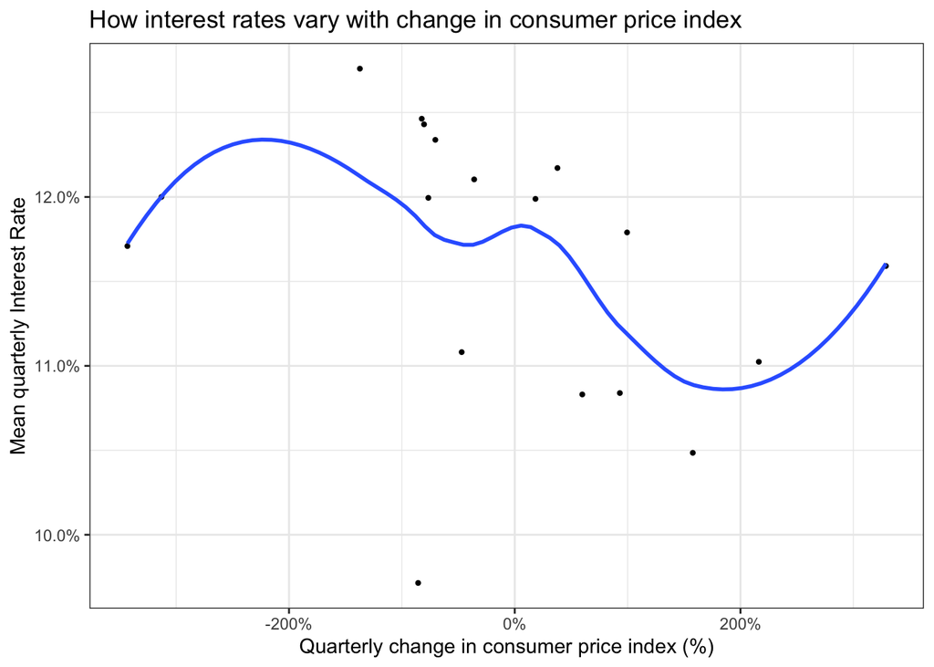

```r
# Visualise the relationship
int_cpi %>%
  ggplot(aes(x = cpi_delta, y = mean_int_rate)) +
  geom_point(size = 0.8) +
  geom_smooth(se = FALSE)+ #line of best fit
  #convert x axis to percentage scale
  scale_x_continuous(labels = scales::percent)+
  #convert y axis to percentage scale
  scale_y_continuous(labels = scales::percent)+
  labs(title = "How interest rates vary with change in consumer price index",
       x = "Quarterly change in consumer price index (%)",
       y = "Mean quarterly Interest Rate")+
  theme_bw()
```

```r
newmodel<-train(
    int_rate ~ loan_amnt + term + loan_amnt:Grade + log(annual_inc) + Grade +
    Price + Grade:Price + #variables from best model
    cpi_delta + Grade:cpi_delta + term:cpi_delta, #variables derived from cpi
    data = lc_with_cpi,
    method = "lm",
    trControl = control
   )
summary(newmodel)
```

```
##
## Call:
## lm(formula = .outcome ~ ., data = dat)
##
## Residuals:
##       Min        1Q    Median        3Q       Max
## -0.116681 -0.005404 -0.000196  0.006110  0.039698
##
## Coefficients:
##                      Estimate Std. Error t value Pr(>|t|)
## (Intercept)         5.699e-02  1.121e-03  50.827  < 2e-16 ***
## loan_amnt           2.855e-07  1.782e-08  16.021  < 2e-16 ***
## term60              2.779e-03  1.302e-04  21.340  < 2e-16 ***
## `log(annual_inc)`  -3.563e-04  9.236e-05  -3.858 0.000115 ***
## GradeB              5.791e-02  7.415e-04  78.107  < 2e-16 ***
## GradeC              9.963e-02  8.233e-04 121.006  < 2e-16 ***
## GradeD              1.328e-01  9.602e-04 138.323  < 2e-16 ***
## GradeE              1.537e-01  1.307e-03 117.636  < 2e-16 ***
## GradeF              1.759e-01  2.035e-03  86.399  < 2e-16 ***
## GradeG              1.969e-01  3.790e-03  51.941  < 2e-16 ***
## Price               6.433e-03  1.776e-04  36.230  < 2e-16 ***
## cpi_delta          -3.669e-03  6.611e-05 -55.501  < 2e-16 ***
## `loan_amnt:GradeB` -2.286e-07  2.115e-08 -10.809  < 2e-16 ***
## `loan_amnt:GradeC` -3.425e-07  2.269e-08 -15.096  < 2e-16 ***
## `loan_amnt:GradeD` -1.148e-07  2.414e-08  -4.757 1.98e-06 ***
## `loan_amnt:GradeE` -3.431e-08  2.615e-08  -1.312 0.189548
## `loan_amnt:GradeF` -2.757e-08  3.602e-08  -0.765 0.444065
## `loan_amnt:GradeG` -1.994e-07  6.357e-08  -3.136 0.001712 **
## `GradeB:Price`     -7.084e-03  2.376e-04 -29.812  < 2e-16 ***
## `GradeC:Price`     -1.253e-02  2.604e-04 -48.104  < 2e-16 ***
## `GradeD:Price`     -1.745e-02  3.068e-04 -56.877  < 2e-16 ***
## `GradeE:Price`     -1.900e-02  4.204e-04 -45.195  < 2e-16 ***
## `GradeF:Price`     -1.994e-02  6.504e-04 -30.658  < 2e-16 ***
## `GradeG:Price`     -2.023e-02  1.176e-03 -17.212  < 2e-16 ***
## `GradeB:cpi_delta`  9.404e-04  9.170e-05  10.255  < 2e-16 ***
## `GradeC:cpi_delta`  3.618e-03  1.004e-04  36.035  < 2e-16 ***
## `GradeD:cpi_delta`  3.964e-03  1.188e-04  33.352  < 2e-16 ***
## `GradeE:cpi_delta`  3.679e-03  1.530e-04  24.053  < 2e-16 ***
## `GradeF:cpi_delta`  3.542e-03  2.346e-04  15.094  < 2e-16 ***
## `GradeG:cpi_delta`  3.219e-03  3.749e-04   8.587  < 2e-16 ***
## `term60:cpi_delta` -8.030e-04  7.475e-05 -10.743  < 2e-16 ***
## ---
## Signif. codes:  0 '***' 0.001 '**' 0.01 '*' 0.05 '.' 0.1 ' ' 1
##
## Residual standard error: 0.008965 on 37837 degrees of freedom
## Multiple R-squared:  0.9422, Adjusted R-squared:  0.9421
## F-statistic: 2.055e+04 on 30 and 37837 DF,  p-value: < 2.2e-16
```